# Practice Activity 6.1

Author

Kabir Wagle

Published

November 3, 2023

```python
import sklearn
import pandas as pd
import numpy as np
```

```python
from sklearn.neighbors import KNeighborsRegressor
from sklearn.tree import DecisionTreeRegressor
from sklearn.linear_model import LinearRegression
from sklearn.model_selection import train_test_split
from sklearn.metrics import mean_squared_error
from sklearn.preprocessing import PolynomialFeatures
```

```python
from plotnine import ggplot, aes, geom_point, geom_line, labs
```

# Palmer Penguins Modeling

Import the Palmer Penguins dataset and print out the first few rows.

Suppose we want to predict `bill_depth_mm` using the other variables in the dataset.

Which variables would we need to **dummify**?

```python
from palmerpenguins import load_penguins
penguins = load_penguins()
penguins.head(3)
```

|  | species | island | bill_length_mm | bill_depth_mm | flipper_length_mm | body_mass_g | sex | year |
| --- | --- | --- | --- | --- | --- | --- | --- | --- |
| 0 | Adelie | Torgersen | 39.1 | 18.7 | 181.0 | 3750.0 | male | 2007 |
| 1 | Adelie | Torgersen | 39.5 | 17.4 | 186.0 | 3800.0 | female | 2007 |
| 2 | Adelie | Torgersen | 40.3 | 18.0 | 195.0 | 3250.0 | female | 2007 |

We would need to dummify the variables Species, Island, and Sex. I have done so below.

```python
df = pd.get_dummies(penguins, columns = ['species', 'island', 'sex'])
df.head(3)
```

|  | bill_length_mm | bill_depth_mm | flipper_length_mm | body_mass_g | year | species_Adelie | species_Chinstrap | species_Gentoo | island_Biscoe | island_Dream | island_Torgersen | sex_female | sex_male |
| --- | --- | --- | --- | --- | --- | --- | --- | --- | --- | --- | --- | --- | --- |
| 0 | 39.1 | 18.7 | 181.0 | 3750.0 | 2007 | True | False | False | False | False | True | False | True |
| 1 | 39.5 | 17.4 | 186.0 | 3800.0 | 2007 | True | False | False | False | False | True | True | False |
| 2 | 40.3 | 18.0 | 195.0 | 3250.0 | 2007 | True | False | False | False | False | True | True | False |

Let’s use `bill_length_mm` to predict `bill_depth_mm`. Prepare your data and fit the following models on the entire dataset:

- Simple linear regression (e.g. straight-line) model
- Quadratic (degree 2 polynomial) model
- Cubic (degree 3 polynomial) model
- Degree 10 polynomial model

Make predictions for each model and plot your fitted models on the scatterplot.

```python
#Remove NA values for regression
penguins = penguins.dropna()
```

```python
#Linear Model
y = penguins['bill_depth_mm']
x = penguins[['bill_length_mm']]

lr = LinearRegression()
lr_fit = lr.fit(x, y)

x_range = pd.DataFrame(np.arange(x.min()[0], x.max()[0] + 1))
y_pred = pd.DataFrame(lr_fit.predict(x_range))
regression = pd.concat([x_range, y_pred], axis = 1)
regression.columns = ['x_range', 'y_pred']
```

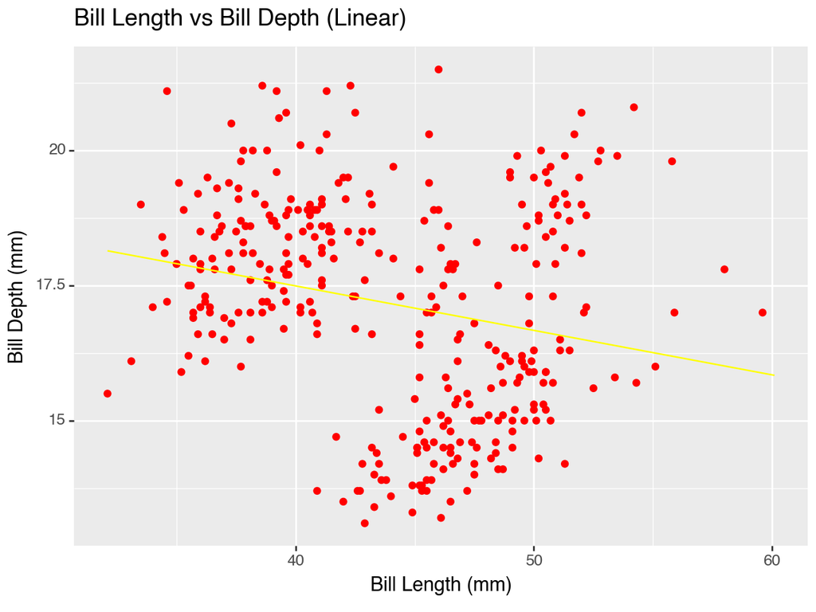

```
<Figure Size: (640 x 480)>
```

```python
#Linear Model Plot
(ggplot(penguins, aes(x = 'bill_length_mm', y = 'bill_depth_mm'))
+ geom_point(color = 'red')
+ geom_line(regression, aes(x = 'x_range', y = 'y_pred'), color = 'yellow')
+ labs(title = 'Bill Length vs Bill Depth (Linear)', x = 'Bill Length (mm)', y = 'Bill Depth (mm)')
)
```

```python
#Quadratic Model
penguins['bill_length_mm^2'] = penguins['bill_length_mm'] ** 2

y = penguins['bill_depth_mm']
x = penguins[['bill_length_mm^2']]

poly = PolynomialFeatures(degree = 2)
x_poly = poly.fit_transform(x)

lr = LinearRegression()
lr_fit = lr.fit(x_poly, y)

x_range = pd.DataFrame(np.arange(x.min()[0], x.max()[0] + 1))
x_range_poly = poly.transform(x_range)
y_pred = pd.DataFrame(lr_fit.predict(x_range_poly))
regression = pd.concat([x_range, y_pred], axis = 1)
regression.columns = ['x_range_poly', 'y_pred']
```

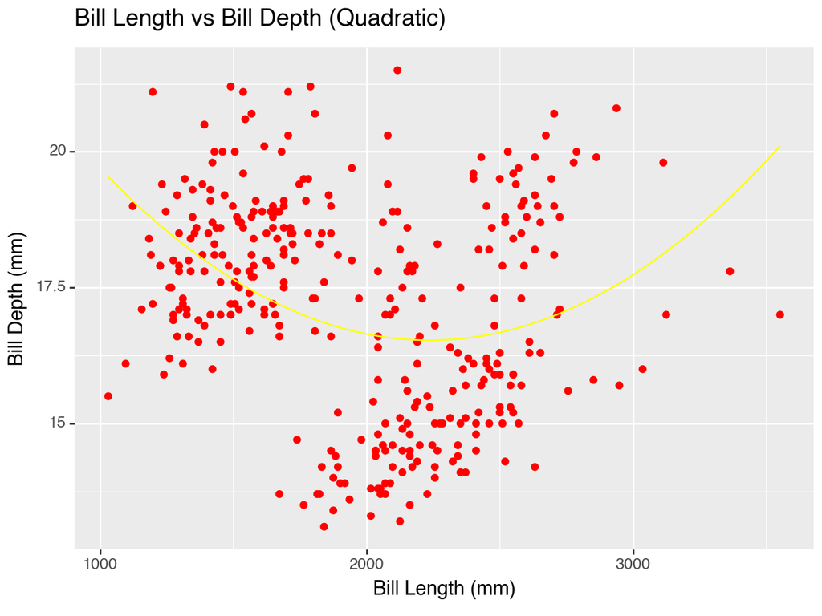

```
<Figure Size: (640 x 480)>
```

```python
#Quadratic Model Plot
(ggplot(penguins, aes(x = 'bill_length_mm^2', y = 'bill_depth_mm'))
+ geom_point(color = 'red')
+ geom_line(regression, aes(x = 'x_range_poly', y = 'y_pred'), color = 'yellow')
+ labs(title = 'Bill Length vs Bill Depth (Quadratic)', x = 'Bill Length (mm)', y = 'Bill Depth (mm)')
)
```

```python
#Cubic Model
penguins['bill_length_mm^3'] = penguins['bill_length_mm'] ** 3

y = penguins['bill_depth_mm']
x = penguins[['bill_length_mm^3']]

poly = PolynomialFeatures(degree = 3)
x_poly = poly.fit_transform(x)

lr = LinearRegression()
lr_fit = lr.fit(x_poly, y)

x_range = pd.DataFrame(np.arange(x.min()[0], x.max()[0] + 1))
x_range_poly = poly.transform(x_range)
y_pred = pd.DataFrame(lr_fit.predict(x_range_poly))
regression = pd.concat([x_range, y_pred], axis = 1)
regression.columns = ['x_range_poly', 'y_pred']
```

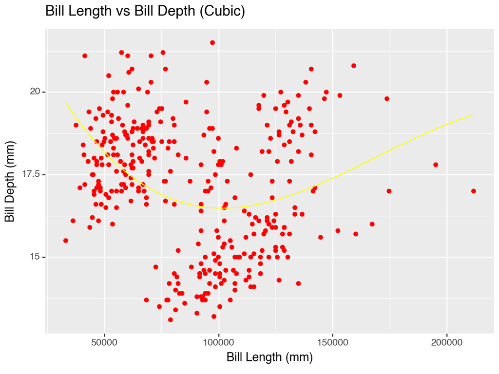

```
<Figure Size: (640 x 480)>
```

```python
#Cubic Model Plot
(ggplot(penguins, aes(x = 'bill_length_mm^3', y = 'bill_depth_mm'))
+ geom_point(color = 'red')
+ geom_line(regression, aes(x = 'x_range_poly', y = 'y_pred'), color = 'yellow')
+ labs(title = 'Bill Length vs Bill Depth (Cubic)', x = 'Bill Length (mm)', y = 'Bill Depth (mm)')
)
```

```python
#Degree 10 Model (Was too large to run)
penguins['bill_length_mm^10'] = penguins['bill_length_mm'] ** 10

y = penguins['bill_depth_mm']
x = penguins[['bill_length_mm^10']]

poly = PolynomialFeatures(degree = 10)
x_poly = poly.fit_transform(x)

lr = LinearRegression()
lr_fit = lr.fit(x_poly, y)

x_range = pd.DataFrame(np.arange(x.min()[0], x.max()[0] + 1))
x_range_poly = poly.transform(x_range)
y_pred = pd.DataFrame(lr_fit.predict(x_range_poly))
regression = pd.concat([x_range, y_pred], axis = 1)
regression.columns = ['x_range_poly', 'y_pred']
```

```
MemoryError: Unable to allocate 3.92 EiB for an array with shape (564377466057414336,) and data type float64
```

```python
#Degree 10 Model Plot
(ggplot(penguins, aes(x = 'bill_length_mm^10', y = 'bill_depth_mm'))
+ geom_point(color = 'red')
+ geom_line(regression, aes(x = 'x_range_poly', y = 'y_pred'), color = 'yellow')
+ labs(title = 'Bill Length vs Bill Depth (Degree 10)', x = 'Bill Length (mm)', y = 'Bill Depth (mm)')
)
```

[output not shown]

- Are any of the models above underfitting the data? If so, which ones and how can you tell?
- Are any of thhe models above overfitting the data? If so, which ones and how can you tell?
- Which of the above models do you think fits the data best and why?

I was only able to produce the first three plots, so I’ll focus on them for the analysis.

The linear model shows a clear negative relationship between bill length and bill depth. However, it does not quite capture the intricacies of the dataset. The scatterplot shows two clear clusters of penguins. A cluster of short bill length penguins with longer bill depth, as well as a clsuter of mid-sized bill length penguins with shorter bill depth. These are not reflected well in the linear model meaning that it is underfitting the data.

The quadratic model does a much better job of capturing the pattern of the data through it’s curvature. It has a U shape that matches the dip in bill depth for mid-sized bill length penguins. However, there is a sharp increase in bill depth for longer bill length penguins that is over exaggerated given the number of data points. The quadratic model is appropriately fit for the most part, and is overfitted for larger values of bill length.

The cubic model is very similar to the quadratic model in terms of shape. It follows that same U pattern and is overfit for large values of y. However, the slope of the curve for the cubic model is less dramatic. Visually, the cubic model better represents the dataset. However, there is not much that seperates the cubic and quadratic models.